# R_handy_commands

## Graphics and Pretty Output

### Plot data generically P

```
  plot(variable1, variable2, ...)

  OR

  plot(dataset)
```

R will choose the appropriate plot based on the type of data you’ve asked it to plot

e.g.

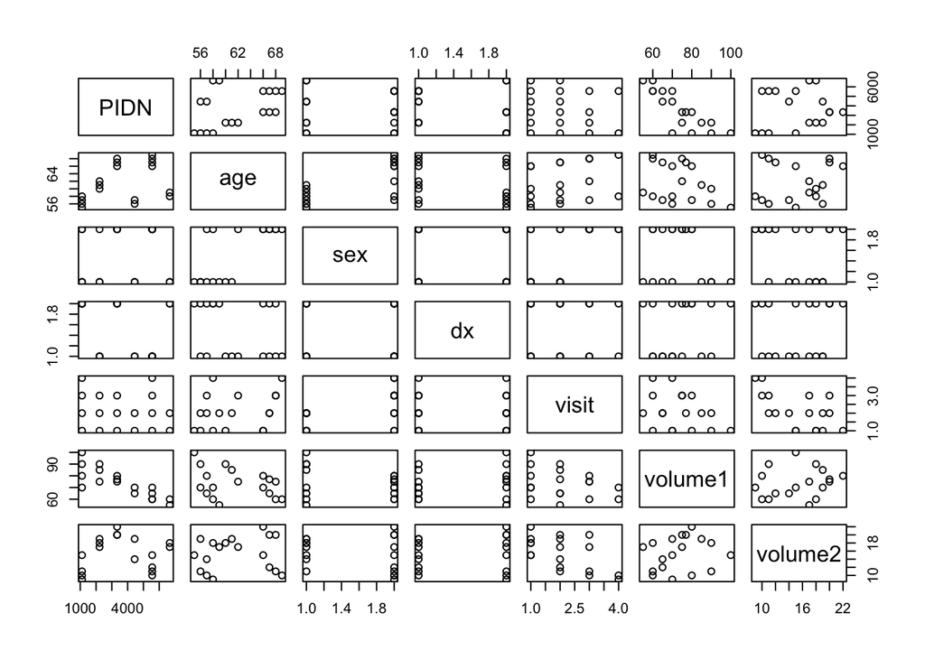

```r
 plot(test.frame.local)
```

OR

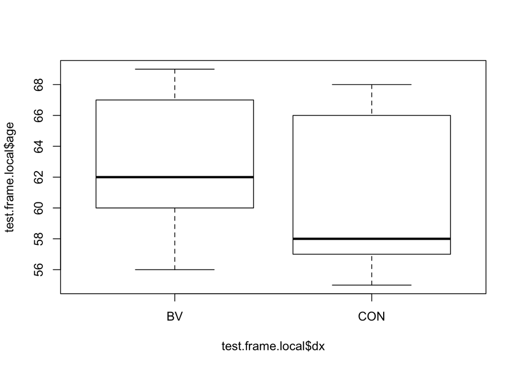

```r
 plot(test.frame.local$age~test.frame.local$dx)
```

OR

e.g.

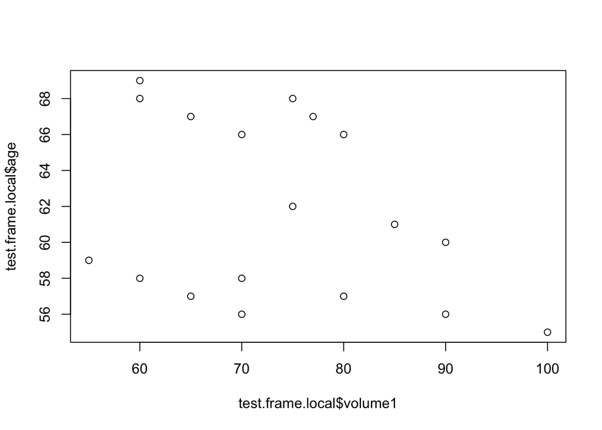

```r
 plot(test.frame.local$age~test.frame.local$volume1)
```

### Labelling Plots

```
  xlab = "text"
  ylab = "text"
  main= "text"
```

e.g

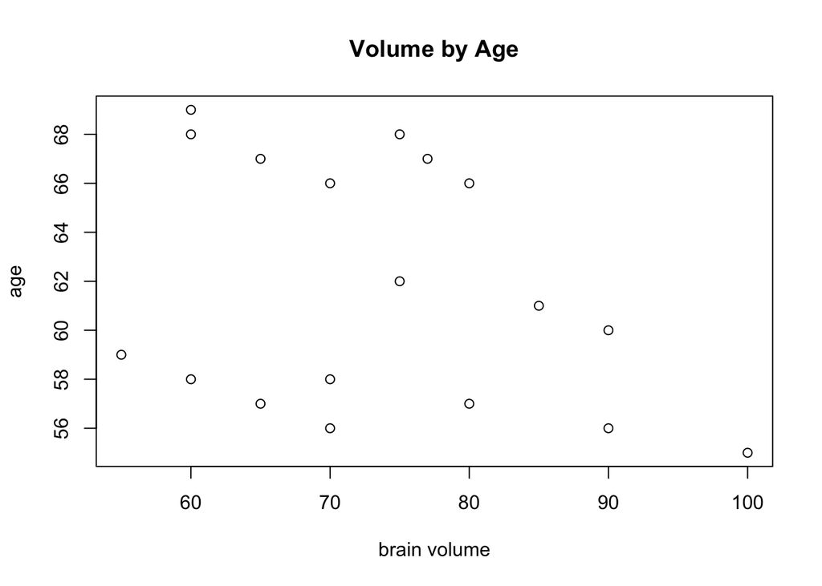

```r
 plot(test.frame.local$age~test.frame.local$volume1, xlab="brain volume", ylab = "age", main = "Volume by Age")
```

### Boxplots

```
  boxplot   Boxplot(dataset_name$variable)
```

If you want to do conditional plot using lattice package version, use:

```
  bwplot(factor_variable~numeric_variable)
```

e.g.

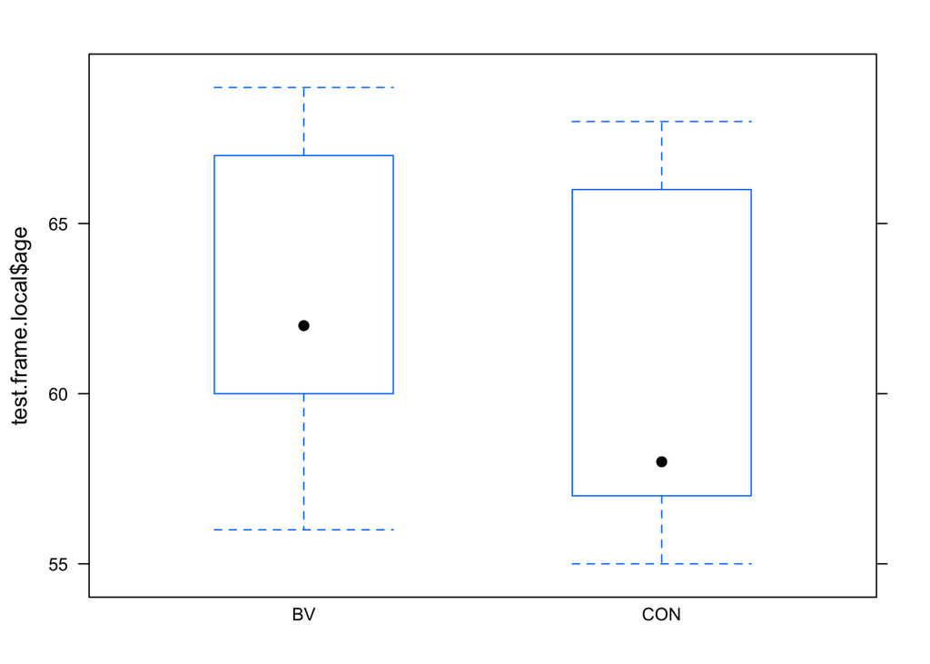

```r
library(lattice)
bwplot(test.frame.local$age~test.frame.local$dx)
```

### Histograms

```
  hist(dataset_name$variable)
```

This will give counts for each interval

```
  hist(dataset_name$variable, prob = TRUE)
```

This will give probabilities for each interval instead of counts

If you want to use teh version from the lattice package:

```
  library(lattice)
  Histogram( ~ variable | factor_variable, data = dataset_name)
```

OR

```
  Histogram(condition ~ variable | condition, data = dataset_name, type = “statistic”, nint=number_of_bins)
```

Type can be “percent”, “count”, or “density”

e.g.

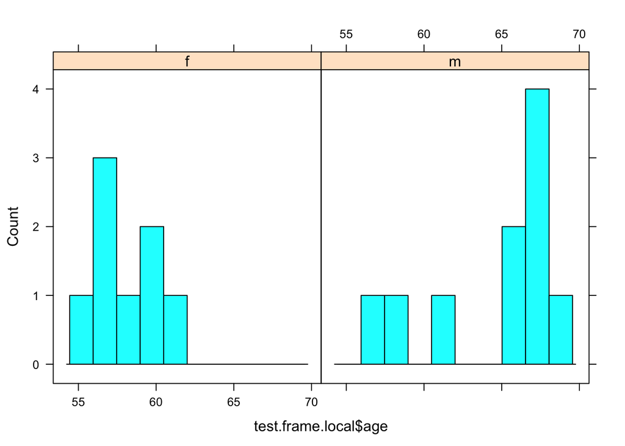

```r
library(lattice)
histogram(~test.frame.local$age | test.frame.local$sex, type = "count", nint = 10)
```

### Scatterplot

```
  scatterplot(variable1~variable2, smoother=FALSE)

  OR, to separate plots by categorical variable:

  scatterplot(variable1~variable2 | factor_variable, smoother=FALSE)
```

e.g.

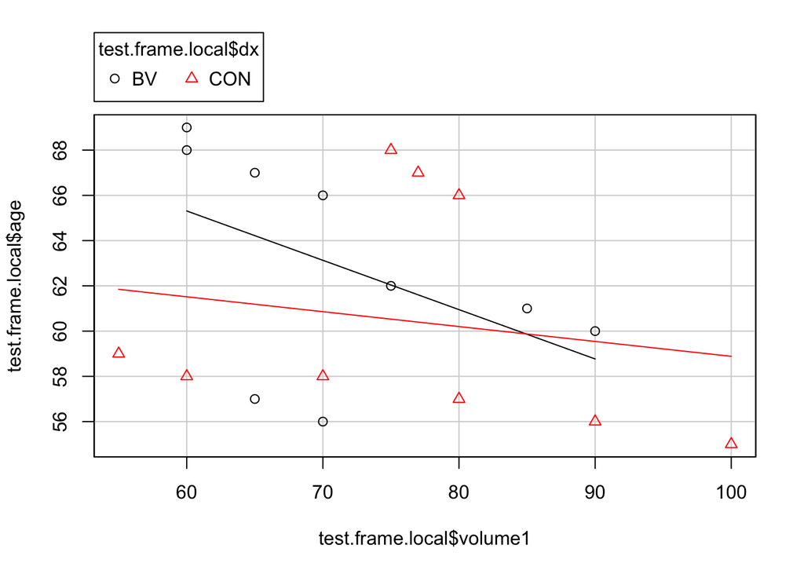

```r
library(car)
scatterplot(test.frame.local$age~test.frame.local$volume1 | test.frame.local$dx, smoother=FALSE)
```

### Make a nice table in markdown

```
  library(knitr)
  knitr::kable(table_name. col_names = "column_names")
```

e.g.

The following commands will output a nice table if you run in R markdown and Knit Word. This will be able to be formatted and handled in word like any other table

```r
sex_tab <- table(test.frame.local$sex, test.frame.local$dx)
library(knitr)
knitr::kable(sex_tab)
```

|  | BV | CON |
| --- | --- | --- |
| f | 4 | 4 |
| m | 5 | 5 |

In this case, it used the names of the levels in diagnosis and sex as column names

But, you can specify the column names

e.g.

```r
means_table <- aggregate(test.frame.local$age ~ test.frame.local$dx + test.frame.local$sex, FUN=mean)
library(knitr)
knitr::kable(means_table, col.names = c("Diagnosis", "Sex", "Mean Age"))
```

| Diagnosis | Sex | Mean Age |
| --- | --- | --- |
| BV | f | 58.5 |
| CON | f | 57.0 |
| BV | m | 66.4 |
| CON | m | 63.2 |